# Predicting Weight Lift Quality with Multiple Accelerometers

A. Nonymous

22/02/2015

## Initialisation and Data Preprocessing

Some required libraries are loaded, then the training set given is split further into train and test sets for cross-validation purposes.

```r
library(caret)
library(plyr)
library(RANN)
library(randomForest)
raw_train    <- read.csv('pml-training.csv')
validation  <- read.csv('pml-testing.csv')

set.seed(78910)
train_idx <- createDataPartition(y=raw_train$classe, list=FALSE, p=0.6)
train     <- raw_train[train_idx, ]
test      <- raw_train[-train_idx, ]
```

We have 159 potential predictor variables, including *classe*, so we can afford to be fairly brutal in our initial pruning. A model fit will be attempted on the result, and after cross-validation of results we may return to this step. First of all, all non-numeric variables are discarded. Next variables with near-zero variance are discarded. The all-numeric dataset allows the use of K-nearest-neighbour imputation via caret, and in the same command PCA is performed to reduce the dimensionality of the problem. This results in a predictor vector only 30 long for each item, a significant reduction. Note that the preprocessor is created only from the training set, and then used to apply the same processing to both test and validation sets.

```r
numerics <- which(lapply(train,class) %in% c('numeric'))
train_class <- train[ ,160]
test_class  <- test[ ,160]
validation_probid <- validation[ ,160]

train <- train[, numerics]
test  <- test[, numerics]
validation <- validation[, numerics]

nzv <- nearZeroVar(train)
train <- train[-nzv]
test  <- test[-nzv]
validation <- validation[-nzv]

imputer <- preProcess(train, method=c('knnImpute','pca'))

train <- predict(imputer, train)
test  <- predict(imputer, test)
validation <- predict(imputer, validation)
```

## Model Fit

Next a random forest model is trained on the training set data. The first run of this was performed using caret, as in the commented line, which found an optimal mtry parameter. As this takes a number of hours to compute it has been left out for the purposes of producing this document, though I will try to update the gh-pages after submission to demonstrate it and provide a graph of mtry vs accuracy. The default value calculated by randomForest is 5, which works. This parameter sets the number of candidate variables selected as potential splitters at each branch of the tree.

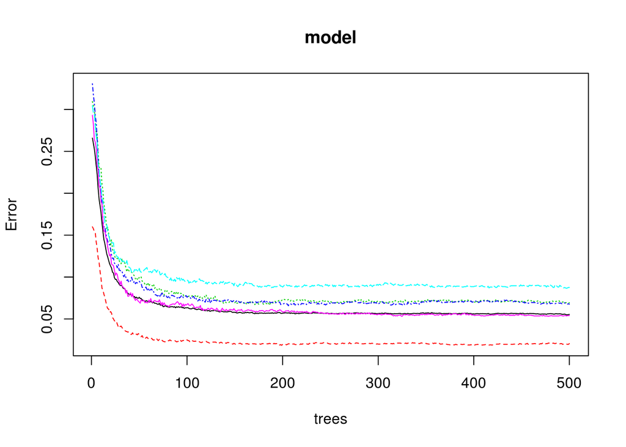

```r
#model <- train(train, train_class, method='rf', ntree=500)
model <- randomForest(train, train_class, ntree=500)
plot(model)
```

## In- and Out-of-sample error

```r
train_pred <- predict(model, train)
confusionMatrix(train_pred, train_class)
```

```
## Confusion Matrix and Statistics
##
##           Reference
## Prediction    A    B    C    D    E
##          A 3348    0    0    0    0
##          B    0 2279    0    0    0
##          C    0    0 2054    0    0
##          D    0    0    0 1930    0
##          E    0    0    0    0 2165
##
## Overall Statistics
##
##                Accuracy : 1
##                  95% CI : (0.9997, 1)
##     No Information Rate : 0.2843
##     P-Value [Acc > NIR] : < 2.2e-16
##
##                   Kappa : 1
##  Mcnemar's Test P-Value : NA
##
## Statistics by Class:
##
##                      Class: A Class: B Class: C Class: D Class: E
## Sensitivity            1.0000   1.0000   1.0000   1.0000   1.0000
## Specificity            1.0000   1.0000   1.0000   1.0000   1.0000
## Pos Pred Value         1.0000   1.0000   1.0000   1.0000   1.0000
## Neg Pred Value         1.0000   1.0000   1.0000   1.0000   1.0000
## Prevalence             0.2843   0.1935   0.1744   0.1639   0.1838
## Detection Rate         0.2843   0.1935   0.1744   0.1639   0.1838
## Detection Prevalence   0.2843   0.1935   0.1744   0.1639   0.1838
## Balanced Accuracy      1.0000   1.0000   1.0000   1.0000   1.0000
```

This confusion matrix shows that in-sample error is zero, as accuracy is 100%. This could be an indicator of overfitting, but out-of-sample error should be investigated before making any conclusions.

```r
test_pred <- predict(model, test)
confusionMatrix(test_pred, test_class)
```

```
## Confusion Matrix and Statistics
##
##           Reference
## Prediction    A    B    C    D    E
##          A 2198   59    2   11    7
##          B   20 1396   35   11   17
##          C    7   36 1284   62   18
##          D    1   12   31 1174   19
##          E    6   15   16   28 1381
##
## Overall Statistics
##
##                Accuracy : 0.9474
##                  95% CI : (0.9422, 0.9522)
##     No Information Rate : 0.2845
##     P-Value [Acc > NIR] : < 2.2e-16
##
##                   Kappa : 0.9334
##  Mcnemar's Test P-Value : 5.404e-06
##
## Statistics by Class:
##
##                      Class: A Class: B Class: C Class: D Class: E
## Sensitivity            0.9848   0.9196   0.9386   0.9129   0.9577
## Specificity            0.9859   0.9869   0.9810   0.9904   0.9899
## Pos Pred Value         0.9653   0.9439   0.9126   0.9491   0.9550
## Neg Pred Value         0.9939   0.9808   0.9870   0.9831   0.9905
## Prevalence             0.2845   0.1935   0.1744   0.1639   0.1838
## Detection Rate         0.2801   0.1779   0.1637   0.1496   0.1760
## Detection Prevalence   0.2902   0.1885   0.1793   0.1577   0.1843
## Balanced Accuracy      0.9853   0.9533   0.9598   0.9517   0.9738
```

## Predicting for Validation (and fun)

Applying this model to the validation set provided gives answers as follows:

```r
answers <- predict(model, validation)
answers
```

```
##  1  2  3  4  5  6  7  8  9 10 11 12 13 14 15 16 17 18 19 20
##  B  A  B  A  A  E  D  B  A  A  B  C  B  A  E  E  A  B  B  B
## Levels: A B C D E
```

These answers have been accepted by the autograder as correct.